# Enron EDA

Giacomo Sarchioni

23 October 2016

# Introduction

This document contains the **Exploratory Data Analysis** of the Enron dataset.

# Exploration

### Univariate analysis

It is quite evident how most of the distributions are positively skewed. This makes sense since the variables represent numerical concepts (e.g. salary, bonuses, but even e-mails sent and received) which typically follow such distributions. Most of the observations have medium-low values, while some few cases are far in the right tail.

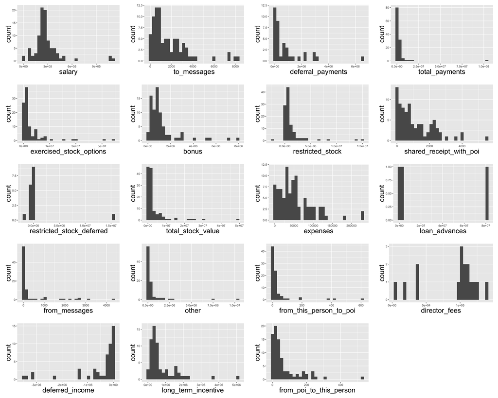

Given the shapes of the distributions, it is worhted to have a look at how transformed distributions (e.g. sqrt and log10) look like. I might do some rescaling at this stage instead of waiting to do it later on during the fitting of features for machine learning algorithms.  
Let me start with **log10** transformations. It is evident how distributions now look more symmetrical.

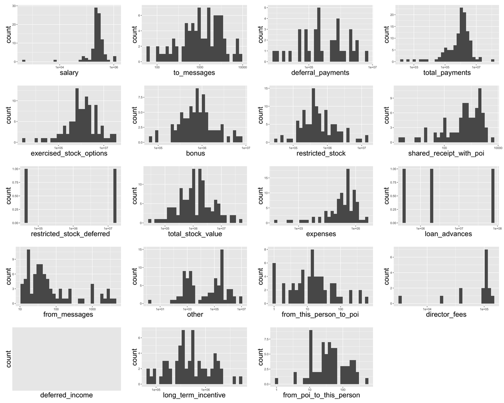

I now do the same with **sqrt** transformations. This transformation seems to work very well with the variable salary.

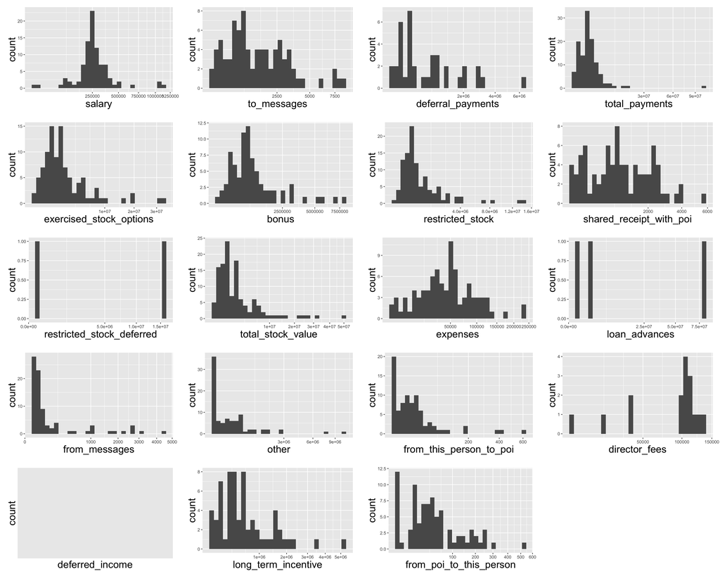

### Bivariate analyis

In this section I will plot some features against each other and comment on some possible relationshisp. This should serve as a kind of “inspirational” exercise in order to inform my decision thinking with regards to the creation of new variables.

#### Salary vs Bonus

The chart below shows the relationship between salary (sqrt-transformed) and bonus (log10-transformed). It is evident how these two variables tell a story. Except for a single observation, all POIs have a bonus above (approximately) 550k USD.

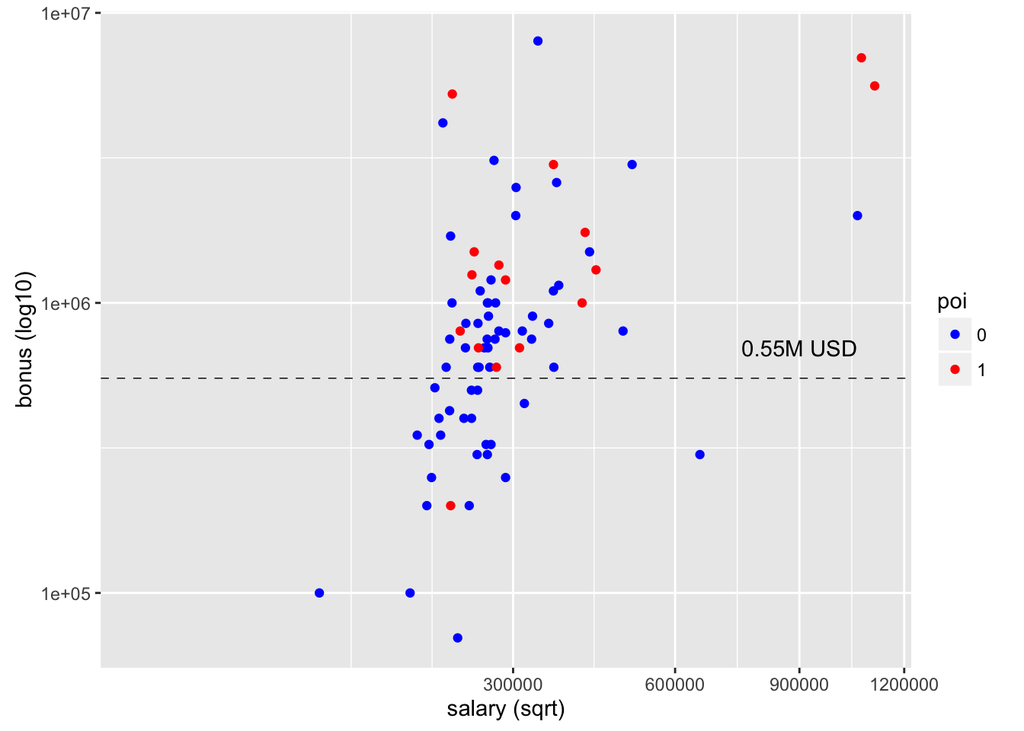

#### Salary vs total stock value

The salary (sqrt-transformed) vs totak stock value (log10-transformed) chart does not seem to bring any significant evidence.

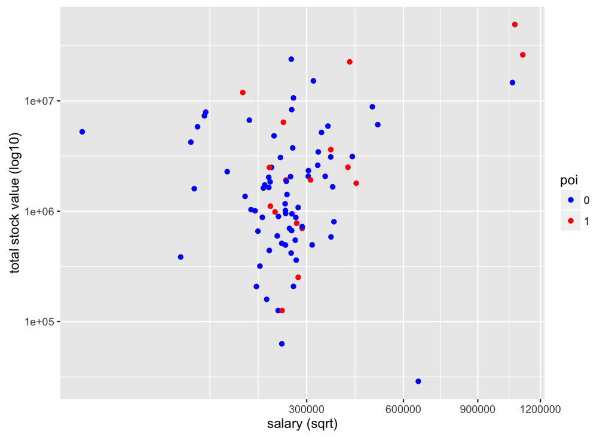

#### Messages sent vs received

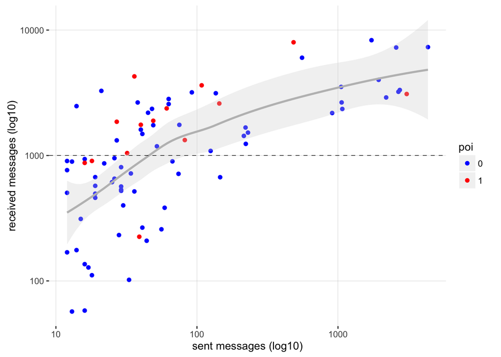

## New variables

I am now going to explore possible new variables. In particular, I am calculating ratios of existing variables. This will allow to capture me proportios rather than absolute values.

### Financial variables

#### Bonus ratio

This variable expresses the bonus as a proportion of salary.

#### Exercised stock ratio

This variable expresses the value of exercised stock as a proportion of total stock.

#### Payments ratio

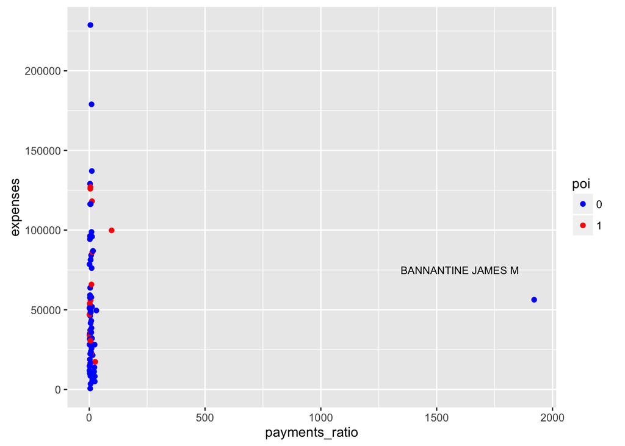

#### Expenses ratio

This variable represents the amount of expenses as a proportion of salary.  
Again, there seems to be an outliere here too, which is the same James Bannantine as before.

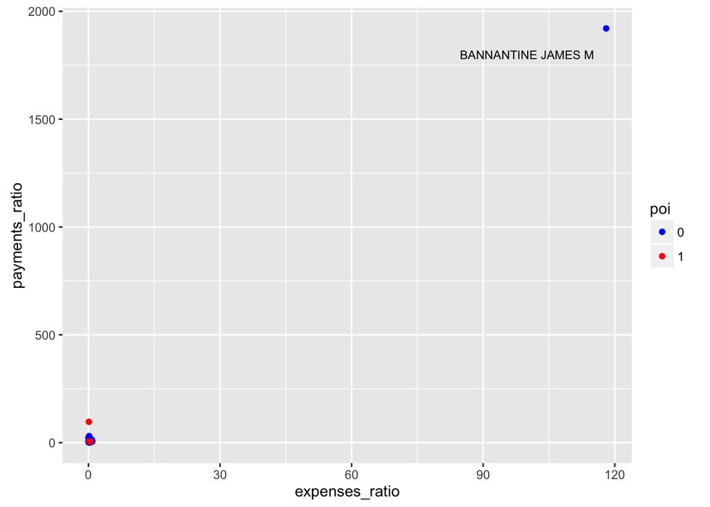

#### Wealth variable

I am also adding a simple feature which represents the total wealth of a person as a result of woring/having worked for Enron. This variable is the sum of salary, bonus and total stock value.  
Note that in the final code I will have to transform NaN values into zero, otherwise wealth (as sum of three variables) might not be calculated correctly.

#### Plotting new financial variables

In order to represent these charts, I am going to create a new dataframe where I exclude James Bannantine.

```r
new_df <- subset(df, name != 'BANNANTINE JAMES M')
```

The chart below shows that Kenneth Lay has an extraordinary high payments_ratio (i.e. he received payments of almost 100 times his salary). Since he is a POI, though, I will not remove it from the dataset.

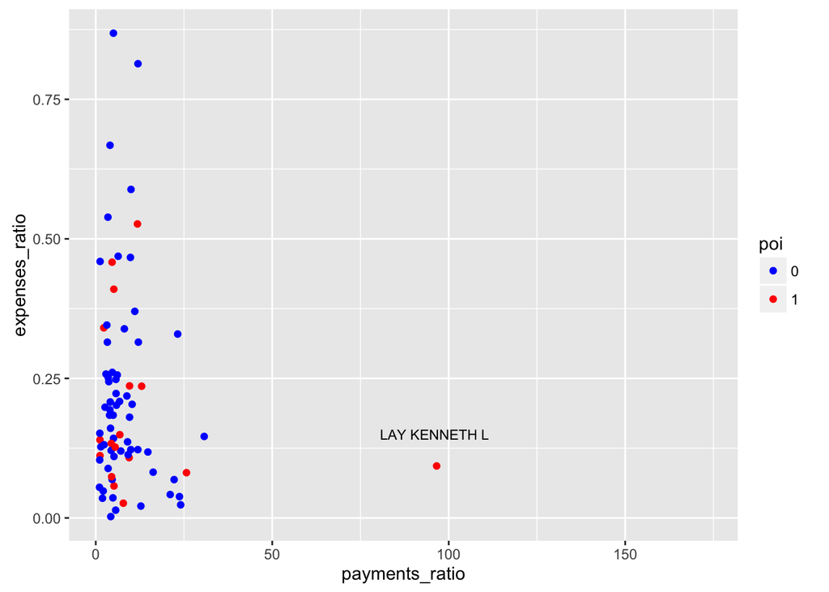

### Messages proportions

For the messagees variable, I am going to create some simple variables which represent the interaction with poi.

#### from_poi_ratio

This variable represents the proportion of e-mail which has been received from a poi out of the total e-mails received.

#### to_poi_ratio

This variable represents the proportion of e-mail which has been sent to a poi out of the total e-mails sent.

#### shared_with_poi_ratio

This variable represents the proportion of e-mail which has been received together with one poi at least, ouf of the total e-mails received.

#### Plotting new messages variable

This will be good material to test in the final algorithms.

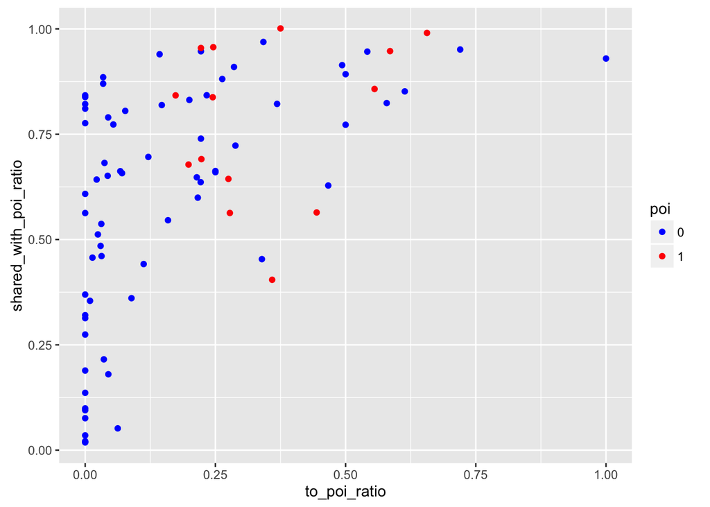